# EX. RESEARCH DESIGN FINAL PROJECT

Della Gatta Antonio

```r
#install.packages("palmerpenguins")
library(palmerpenguins)
library(ggplot2)
library(ggpubr)
library(dplyr)
```

# Palmer Penguin data

### dataset

The Palmer penguins dataset by Allison Horst, Alison Hill, and Kristen Gorman was first made publicly available as an R package.

Size measurements, clutch observations, and blood isotope ratios for 344 adult foraging Adelie, Chinstrap, and Gentoo penguins observed on islands in the Palmer Archipelago near Palmer Station, Antarctica.

The variables in the dataset are:

- **species**
- **island**
- **bill length**
- **bill depth**
- **flipper length**
- **body max**
- **sex**
- **year**

```r
dat<- penguins
dat <- na.omit(dat)

dat<- dat[-c(259,260,263), ]

#View(penguins)
#View(dat)

dat
```

```
# A tibble: 330 x 8
   species island    bill_length_mm bill_depth_mm flipper_length_mm body_mass_g
   <fct>   <fct>              <dbl>         <dbl>             <int>       <int>
 1 Adelie  Torgersen           39.1          18.7               181        3750
 2 Adelie  Torgersen           39.5          17.4               186        3800
 3 Adelie  Torgersen           40.3          18                 195        3250
 4 Adelie  Torgersen           36.7          19.3               193        3450
 5 Adelie  Torgersen           39.3          20.6               190        3650
 6 Adelie  Torgersen           38.9          17.8               181        3625
 7 Adelie  Torgersen           39.2          19.6               195        4675
 8 Adelie  Torgersen           41.1          17.6               182        3200
 9 Adelie  Torgersen           38.6          21.2               191        3800
10 Adelie  Torgersen           34.6          21.1               198        4400
# ... with 320 more rows, and 2 more variables: sex <fct>, year <int>
```

### bill length by sex

As a first analysis I would focus my attention on the male and female penguins of the “Adelie” species

Let’s test with a two sample unpaired t-test

H0 : there’s no difference between the bill length of the male and female penguins *(μM=μF)*

H1: there’s difference between the bill length of the male and female penguins *(μM≠μF)*

**display our data**

```r
library(tseries)
library(dplyr)

new_male <- dat %>%
  filter(species == 'Adelie' & sex == 'male')

new_female <- dat %>%
  filter(species == 'Adelie' & sex == 'female')


male<- new_male[,3] #select only value of interest
male<- as.numeric(unlist(male)) #eliminate list

female<- new_female[,3] #select only value of interest
female<- as.numeric(unlist(female)) #eliminate list
```

Let’s display our data in order to see graphically if there are already some difference.

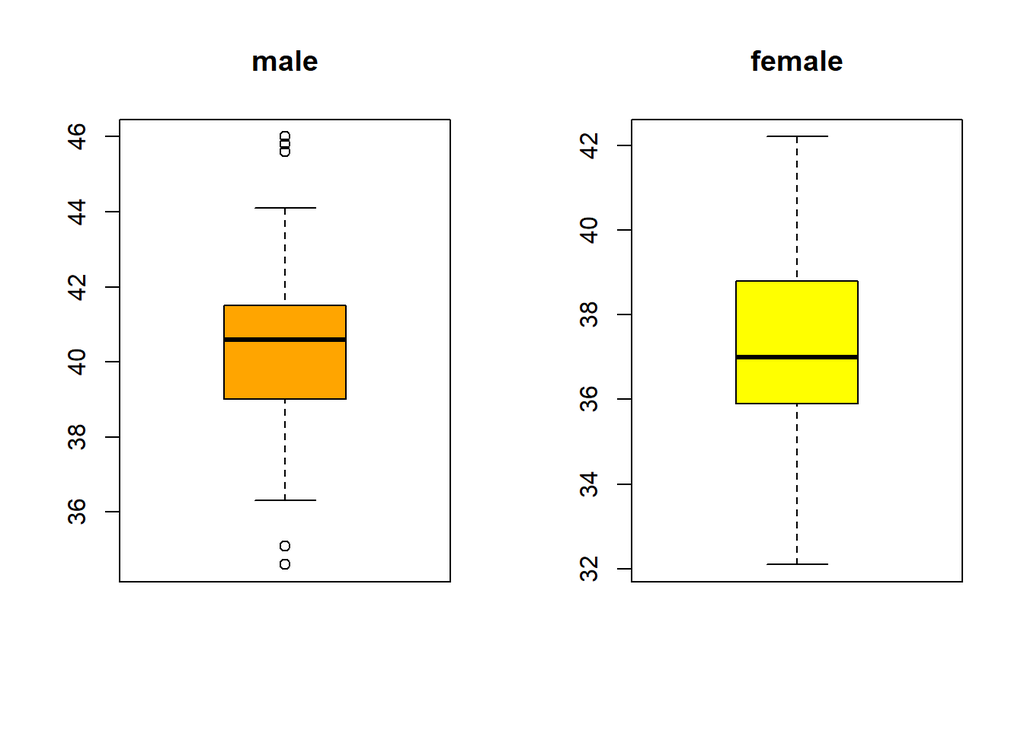

```r
par(mfrow=c(1,2))
boxplot(male, main ="male", col ="orange")
boxplot(female, main = "female", col ="yellow")
```

**check for normality**

```r
shapiro.test(male)
```

```
    Shapiro-Wilk normality test

data:  male
W = 0.98613, p-value = 0.6067
```

```r
shapiro.test(female)
```

```
    Shapiro-Wilk normality test

data:  female
W = 0.99117, p-value = 0.8952
```

since that the value is not less than 0.5 we can say that, our data, are normally distributed.

**we can also display it graphically**

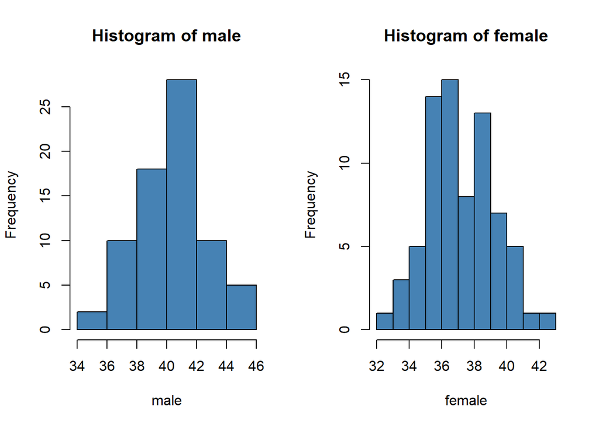

```r
par(mfrow=c(1,2))

x1<- hist(male, col='steelblue')
x2<- hist(female,col='steelblue')
```

**check for “equal” variances**

sd(male)/sd(female) should not be greater than 2.

In this case we’ll use an F- test.\

```r
var.test(male, female,
         alternative = "two.sided")
```

```
    F test to compare two variances

data:  male and female
F = 1.2597, num df = 72, denom df = 72, p-value = 0.3296
alternative hypothesis: true ratio of variances is not equal to 1
95 percent confidence interval:
 0.7907415 2.0067311
sample estimates:
ratio of variances
          1.259685
```

The p-value of **F-test** is p = 0.3296 which is greater than the significance level 0.05. In conclusion, there is no significant difference between the two variances.

So we can say that there’s homogeneity of variances

### check for outliers

```r
par(mfrow=c(1,2))
boxplot(male,main = "male", col ="orange")
outliers_values=boxplot.stats(male)
outliers_values
```

```
$stats
[1] 36.3 39.0 40.6 41.5 44.1

$n
[1] 73

$conf
[1] 40.13769 41.06231

$out
[1] 34.6 46.0 45.8 35.1 45.6
```

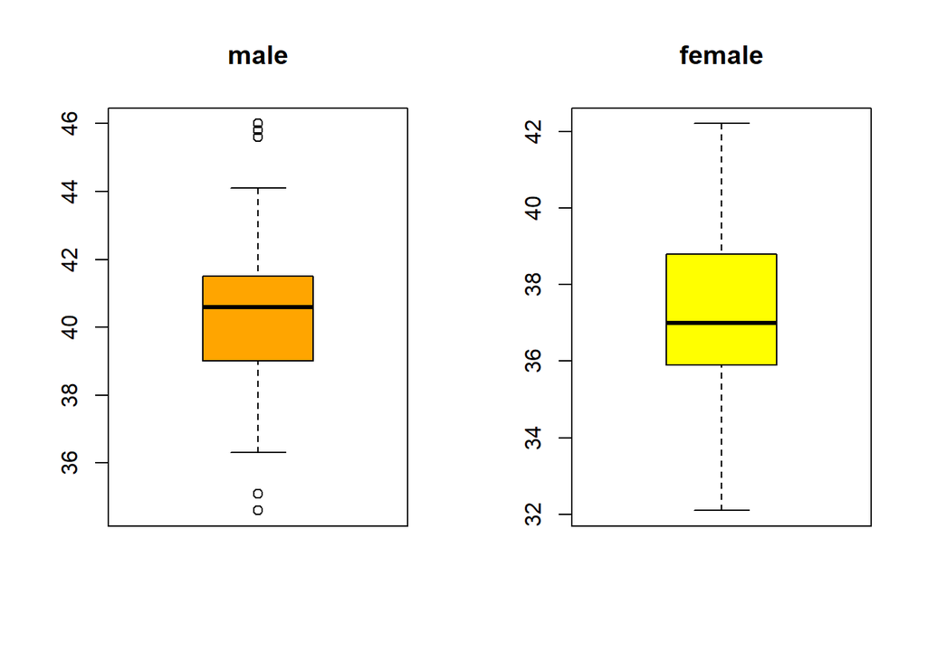

```r
boxplot(female,main = "female", col ="yellow")
```

```r
outliers_values=boxplot.stats(female)$out
outliers_values
```

```
numeric(0)
```

### remove outliers for male

```
[1] 68
```

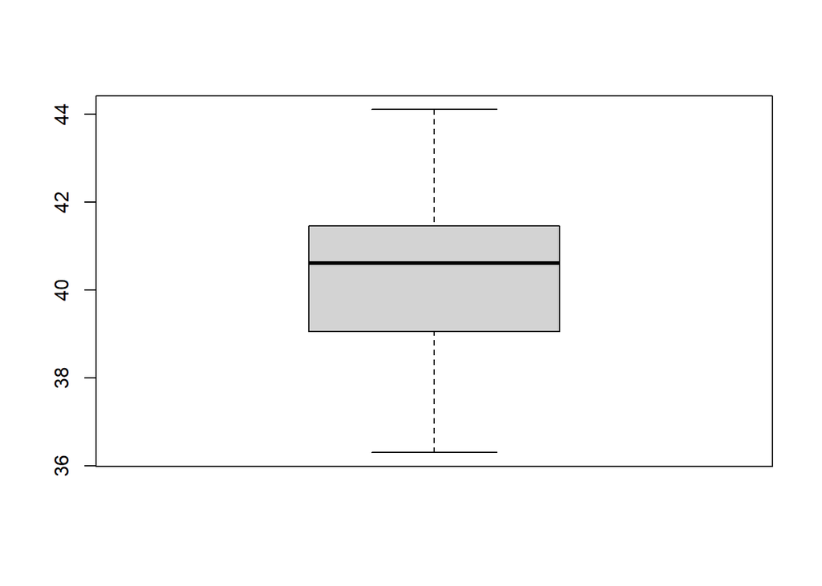

```
   Min. 1st Qu.  Median    Mean 3rd Qu.    Max.
  36.30   39.08   40.60   40.31   41.42   44.10
```

```r
remove_outliers_iqr=function(x){
  IQR=summary(x)[5]-summary(x)[2]
  up_out=summary(x)[5]+1.5*IQR
  down_out=summary(x)[2]-1.5*IQR
  out_data=c(which(x<down_out), which(x>up_out))
  x_new=x[-out_data]
  print(length(x_new))
  boxplot(x_new)
  summary(x_new)}



remove_outliers_iqr(male)
```

now let’s perform our test

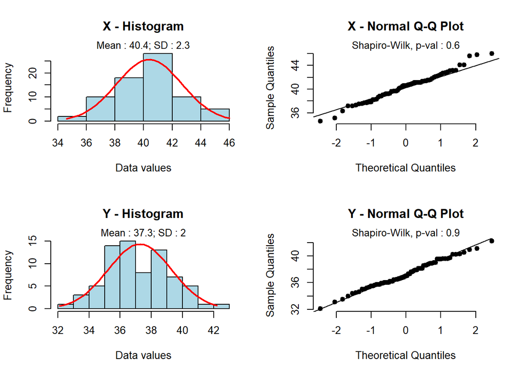

```
    Two Sample t-test

data:  x and y
t = 8.7765, df = 144, p-value = 4.44e-15
alternative hypothesis: true difference in means is not equal to 0
95 percent confidence interval:
 2.427319 3.838435
sample estimates:
mean of x mean of y
 40.39041  37.25753
```

```r
source('http://www.sthda.com/upload/rquery_t_test.r')
rquery.t.test(male, female, paired=FALSE)
```

There aren’t enough evidence to claim that the null hypothesis is true.

The means of the bill length of the penguins are different

## Difference of flipper length by species and sex

Now we can focus our research on the difference of flipper length of three species of penguins.

We can also divide them by sex. The test that we can use is a two way anova.

### Two-way ANOVA test hypotheses

1. There is no difference in the means of first factor
2. There is no difference in means of second factor
3. There is no interaction between factors

The alternative hypothesis for cases 1 and 2 is: the means are not equal.

The alternative hypothesis for case 3 is: there is an interaction between factor

let’s see our data

```r
str(dat)
```

```
tibble [330 x 8] (S3: tbl_df/tbl/data.frame)
 $ species          : Factor w/ 3 levels "Adelie","Chinstrap",..: 1 1 1 1 1 1 1 1 1 1 ...
 $ island           : Factor w/ 3 levels "Biscoe","Dream",..: 3 3 3 3 3 3 3 3 3 3 ...
 $ bill_length_mm   : num [1:330] 39.1 39.5 40.3 36.7 39.3 38.9 39.2 41.1 38.6 34.6 ...
 $ bill_depth_mm    : num [1:330] 18.7 17.4 18 19.3 20.6 17.8 19.6 17.6 21.2 21.1 ...
 $ flipper_length_mm: int [1:330] 181 186 195 193 190 181 195 182 191 198 ...
 $ body_mass_g      : int [1:330] 3750 3800 3250 3450 3650 3625 4675 3200 3800 4400 ...
 $ sex              : Factor w/ 2 levels "female","male": 2 1 1 1 2 1 2 1 2 2 ...
 $ year             : int [1:330] 2007 2007 2007 2007 2007 2007 2007 2007 2007 2007 ...
 - attr(*, "na.action")= 'omit' Named int [1:11] 4 9 10 11 12 48 179 219 257 269 ...
  ..- attr(*, "names")= chr [1:11] "4" "9" "10" "11" ...
```

**Balanced design?**

```r
table(dat$species, dat$sex)
```

```
            female male
  Adelie        73   73
  Chinstrap     34   34
  Gentoo        58   58
```

**display our data**

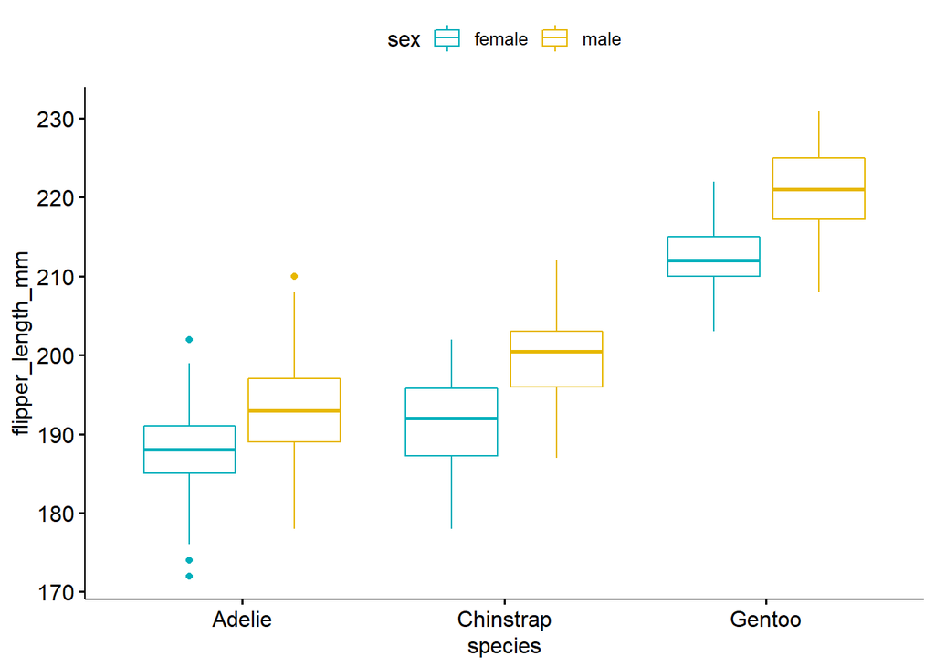

```r
library("ggpubr")

ggboxplot(dat, x = "species", y = "flipper_length_mm", color = "sex",
          palette = c("#00AFBB", "#E7B800"))
```

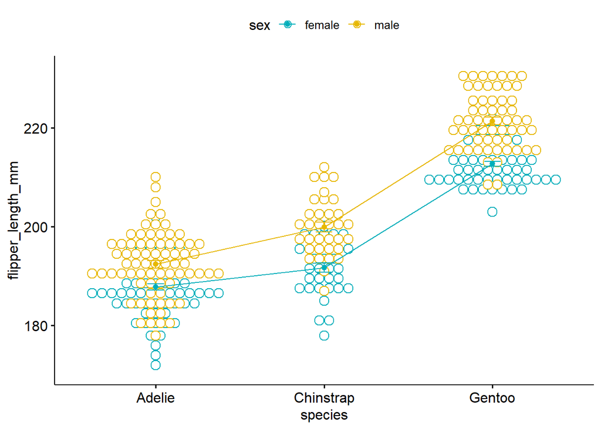

```r
ggline(dat, x = "species", y = "flipper_length_mm", color = "sex",
       add = c("mean_se", "dotplot"),
       palette = c("#00AFBB", "#E7B800"))
```

Remove outliers

there aren’t significant outliers

```r
#find Q1, Q3, and interquartile range for values in column A

df<- dat

Q1 <- quantile(df$flipper_length_mm, .25)
Q3 <- quantile(df$flipper_length_mm, .65)
IQR <- IQR(df$flipper_length_mm)

#only keep rows in dataframe that have values within 1.5*IQR of Q1 and Q3
no_outlier <- subset(df, df$flipper_length_mm > (Q1 - 1.5*IQR) & df$flipper_length_mm < (Q3 + 1.5*IQR))

#view row and column count of new data frame
print("dimension dataset always equal : 330   8")
```

```
[1] "dimension dataset always equal : 330   8"
```

```r
#dim(no_outlier)
```

**Check for normality**

```r
library(rstatix)

 no_outlier %>%
  group_by(species,sex) %>%
  shapiro_test(flipper_length_mm)
```

```
# A tibble: 6 x 5
  species   sex    variable          statistic      p
  <fct>     <fct>  <chr>                 <dbl>  <dbl>
1 Adelie    female flipper_length_mm     0.984 0.491
2 Adelie    male   flipper_length_mm     0.984 0.498
3 Chinstrap female flipper_length_mm     0.972 0.507
4 Chinstrap male   flipper_length_mm     0.975 0.620
5 Gentoo    female flipper_length_mm     0.974 0.245
6 Gentoo    male   flipper_length_mm     0.963 0.0746
```

the p-value is never lower than 0.05

- normality checked

**now let’s run our test**

Two-way interaction plot

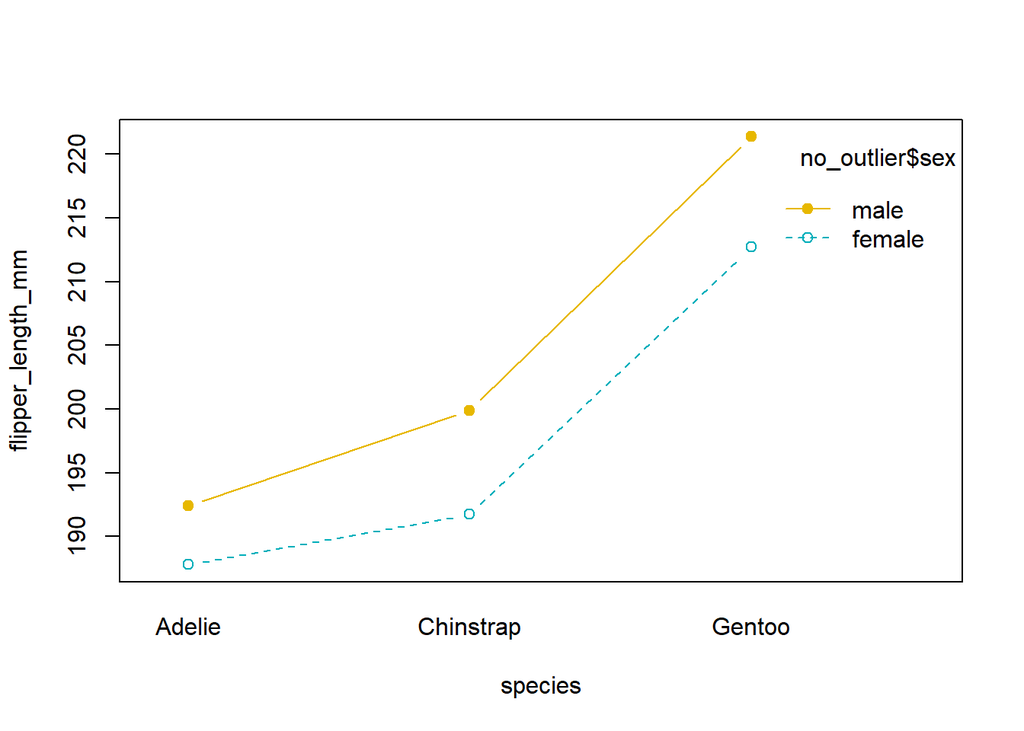

```r
library(stats)
interaction.plot(x.factor = no_outlier$species, trace.factor = no_outlier$sex,
                 response = no_outlier$flipper_length_mm, fun = mean,
                 type = "b", legend = TRUE,
                 xlab = "species", ylab="flipper_length_mm",
                 pch=c(1,19), col = c("#00AFBB", "#E7B800"))
```

```r
mod2 <- aov(flipper_length_mm ~ sex + species, data = no_outlier)
summary(mod2)
```

```
             Df Sum Sq Mean Sq F value Pr(>F)
sex           1   3788    3788   115.5 <2e-16 ***
species       2  48995   24498   746.9 <2e-16 ***
Residuals   326  10692      33
---
Signif. codes:  0 '***' 0.001 '**' 0.01 '*' 0.05 '.' 0.1 ' ' 1
```

```r
mod3 <- aov(flipper_length_mm ~ sex * species, data = no_outlier)
summary(mod3)
```

```
             Df Sum Sq Mean Sq F value Pr(>F)
sex           1   3788    3788 118.175 <2e-16 ***
species       2  48995   24498 764.330 <2e-16 ***
sex:species   2    308     154   4.803 0.0088 **
Residuals   324  10385      32
---
Signif. codes:  0 '***' 0.001 '**' 0.01 '*' 0.05 '.' 0.1 ' ' 1
```

**check for normality of the residuals**

first plot

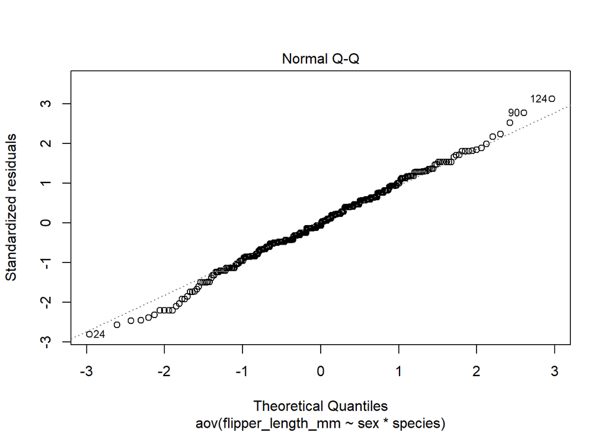

```r
# 2. Normality
plot(mod3, 2)
```

then use the shapiro test

```r
# Extract the residuals
aov_residuals <- residuals(object = mod3)
# Run Shapiro-Wilk test
shapiro.test(x = aov_residuals )
```

```
    Shapiro-Wilk normality test

data:  aov_residuals
W = 0.99565, p-value = 0.4917
```

- checked

**check for HOMOSCEDASTICITY**

first plot residuals

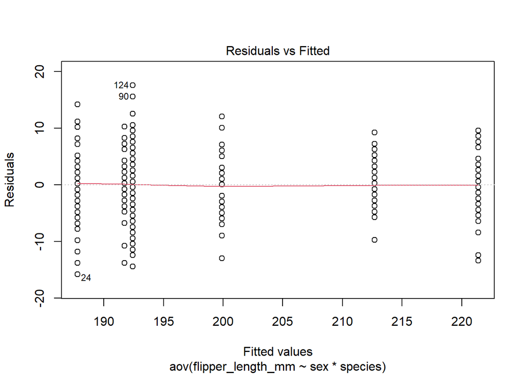

Use the **Levene’s test** to check the **homogeneity of variances**. The function **leveneTest**() [in **car** package] will be used:

```r
library(car)
library(PMCMRplus)
leveneTest(flipper_length_mm ~ species * sex, data = no_outlier)
```

```
## Levene's Test for Homogeneity of Variance (center = median)
##        Df F value  Pr(>F)
## group   5  2.4276 0.03519 *
##       324
## ---
## Signif. codes:  0 '***' 0.001 '**' 0.01 '*' 0.05 '.' 0.1 ' ' 1
```

try another test

```r
hartleyTest(flipper_length_mm ~ interaction(sex,species), data = no_outlier)
```

```
##
##  Hartley's maximum F-ratio test of homogeneity of variances
##
## data:  flipper_length_mm by interaction(sex, species)
## F Max = 2.8665, df = 57, k = 6, p-value = 0.001734
```

```r
library(onewaytests)

welch.test(flipper_length_mm ~ interaction(sex,species), data = no_outlier)
```

```
##
##   Welch's Heteroscedastic F Test (alpha = 0.05)
## -------------------------------------------------------------
##   data : flipper_length_mm and interaction(sex, species)
##
##   statistic  : 358.0201
##   num df     : 5
##   denom df   : 129.3854
##   p.value    : 6.10673e-74
##
##   Result     : Difference is statistically significant.
## -------------------------------------------------------------
```

- **homogeneity of variances not present**

## bill length by island

Another interesting aspect was to understand if the bill length could have changed from an island to another.

So I’ve completed this task thanks to a non parametric test

```r
#View(dat)
new_m <- dat %>%
  filter(island == 'Dream')


new_f <- dat %>%
  filter(island == 'Biscoe')


dream<- new_m[1:100,3] #select only value of interest
dream<- as.numeric(unlist(dream)) #eliminate list

biscoe<- new_f[1:100,3] #select only value of interest
biscoe<- as.numeric(unlist(biscoe)) #eliminate list
```

check normality

```r
shapiro.test(dream)
```

```
    Shapiro-Wilk normality test

data:  dream
W = 0.94772, p-value = 0.0005885
```

```r
shapiro.test(biscoe)
```

```
    Shapiro-Wilk normality test

data:  biscoe
W = 0.96445, p-value = 0.008451
```

the p value is lower than 0.05 so, in this case, the value of the bill length is not normally distributed.

- check variances

```r
fligner.test(dream ~ biscoe)
```

```
    Fligner-Killeen test of homogeneity of variances

data:  dream by biscoe
Fligner-Killeen:med chi-squared = 73.958, df = 72, p-value = 0.414
```

### does the median value of the penguins on the first island differ from the median of the penguin on the second one?

**display our data**

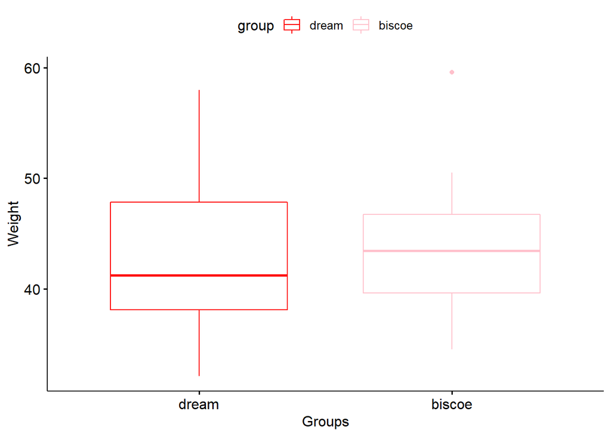

```r
library(tidyverse)
library(rstatix)
library(ggpubr)

my_data <- data.frame(
  group = rep(c("dream", "biscoe"), each = 100),
  weight = c(dream,  biscoe)
)


ggboxplot(my_data, x = "group", y = "weight",

          color = "group", palette = c("red", "pink"),

          ylab = "Weight", xlab = "Groups")
```

**run our test**

```r
res <- wilcox.test(dream , biscoe)

res
```

```
    Wilcoxon rank sum test with continuity correction

data:  dream and biscoe
W = 4819, p-value = 0.6592
alternative hypothesis: true location shift is not equal to 0
```

it doesn’t seem that there’s a real difference.

**effect size**

```r
library(coin)
my_data %>% wilcox_effsize(weight ~ group)
```

```
# A tibble: 1 x 7
  .y.    group1 group2 effsize    n1    n2 magnitude
* <chr>  <chr>  <chr>    <dbl> <int> <int> <ord>
1 weight biscoe dream   0.0313   100   100 small
```

The Wilcoxon test showed that the difference was not significant (p > 0.05, effect size r = 0.0313).